# Part I - Ford GoBike System Data

## by: Ibtisam Alzahrani

## Introduction

> The chosen dataset is `Ford GoBike System Data`. The dataset includes information about individual rides made in a bike-sharing system covering the greater San Francisco Bay area.

## Preliminary Wrangling

```python
# import all packages and set plots to be embedded inline
import numpy as np
import pandas as pd
import seaborn as sns
from datetime import datetime
import matplotlib.pyplot as plt
from importlib import reload
plt=reload(plt)
```

```python
# import data
df = pd.read_csv('fordgobike-tripdata.csv')
```

```python
# check dataset shape (rows, columns)
df.shape
```

```
(183412, 16)
```

```python
df.info()
```

```
<class 'pandas.core.frame.DataFrame'>
RangeIndex: 183412 entries, 0 to 183411
Data columns (total 16 columns):
 #   Column                   Non-Null Count   Dtype
---  ------                   --------------   -----
 0   duration_sec             183412 non-null  int64
 1   start_time               183412 non-null  object
 2   end_time                 183412 non-null  object
 3   start_station_id         183215 non-null  float64
 4   start_station_name       183215 non-null  object
 5   start_station_latitude   183412 non-null  float64
 6   start_station_longitude  183412 non-null  float64
 7   end_station_id           183215 non-null  float64
 8   end_station_name         183215 non-null  object
 9   end_station_latitude     183412 non-null  float64
 10  end_station_longitude    183412 non-null  float64
 11  bike_id                  183412 non-null  int64
 12  user_type                183412 non-null  object
 13  member_birth_year        175147 non-null  float64
 14  member_gender            175147 non-null  object
 15  bike_share_for_all_trip  183412 non-null  object
dtypes: float64(7), int64(2), object(7)
memory usage: 22.4+ MB
```

```python
df.head()
```

|  | duration_sec | start_time | end_time | start_station_id | start_station_name | start_station_latitude | start_station_longitude | end_station_id | end_station_name | end_station_latitude | end_station_longitude | bike_id | user_type | member_birth_year | member_gender | bike_share_for_all_trip |
| --- | --- | --- | --- | --- | --- | --- | --- | --- | --- | --- | --- | --- | --- | --- | --- | --- |
| 0 | 52185 | 2019-02-28 17:32:10.1450 | 2019-03-01 08:01:55.9750 | 21.0 | Montgomery St BART Station (Market St at 2nd St) | 37.789625 | -122.400811 | 13.0 | Commercial St at Montgomery St | 37.794231 | -122.402923 | 4902 | Customer | 1984.0 | Male | No |
| 1 | 42521 | 2019-02-28 18:53:21.7890 | 2019-03-01 06:42:03.0560 | 23.0 | The Embarcadero at Steuart St | 37.791464 | -122.391034 | 81.0 | Berry St at 4th St | 37.775880 | -122.393170 | 2535 | Customer | NaN | NaN | No |
| 2 | 61854 | 2019-02-28 12:13:13.2180 | 2019-03-01 05:24:08.1460 | 86.0 | Market St at Dolores St | 37.769305 | -122.426826 | 3.0 | Powell St BART Station (Market St at 4th St) | 37.786375 | -122.404904 | 5905 | Customer | 1972.0 | Male | No |
| 3 | 36490 | 2019-02-28 17:54:26.0100 | 2019-03-01 04:02:36.8420 | 375.0 | Grove St at Masonic Ave | 37.774836 | -122.446546 | 70.0 | Central Ave at Fell St | 37.773311 | -122.444293 | 6638 | Subscriber | 1989.0 | Other | No |
| 4 | 1585 | 2019-02-28 23:54:18.5490 | 2019-03-01 00:20:44.0740 | 7.0 | Frank H Ogawa Plaza | 37.804562 | -122.271738 | 222.0 | 10th Ave at E 15th St | 37.792714 | -122.248780 | 4898 | Subscriber | 1974.0 | Male | Yes |

### So far i got a couple of to-dos here:

- Convert start_time/end_time to datetime type.
- Convert Member_virth_year to integer type.
- Convert duration from seconds to minutes.
- Drop missing values.
- Perhaps we'll need a day-of-week column to get better insights on trips.

#### Let's start cleaning up!

```python
# make a copy
df_cleaned = df.copy()
```

```python
# drop null values
df_cleaned.dropna(inplace=True)
```

```python
# convert start_time/end_time to datetime
df_cleaned['start_time'] = pd.to_datetime(df_cleaned['start_time'])
df_cleaned['end_time'] = pd.to_datetime(df_cleaned['end_time'])
```

```python
# convert member birth year to int
df_cleaned['member_birth_year'] = df_cleaned['member_birth_year'].astype('int64')
```

```python
# add new column for start_date weekday
df_cleaned['weekday'] = df_cleaned['start_time'].dt.day_name()
```

```python
# convert duration from seconds to minutes
df_cleaned['duration_sec'] = df_cleaned['duration_sec'] / 60
df_cleaned.rename(columns = {'duration_sec' : 'duration_min'}, inplace=True)
```

```python
# convert duration_min to int
df_cleaned['duration_min'] = df_cleaned['duration_min'].astype('int64')
```

```python
# get member birth years from 1950 and up
df_cleaned = df_cleaned[df_cleaned['member_birth_year'] > 1950]
```

```python
df_cleaned.head()
```

|  | duration_min | start_time | end_time | start_station_id | start_station_name | start_station_latitude | start_station_longitude | end_station_id | end_station_name | end_station_latitude | end_station_longitude | bike_id | user_type | member_birth_year | member_gender | bike_share_for_all_trip | weekday |
| --- | --- | --- | --- | --- | --- | --- | --- | --- | --- | --- | --- | --- | --- | --- | --- | --- | --- |
| 0 | 869 | 2019-02-28 17:32:10.145 | 2019-03-01 08:01:55.975 | 21.0 | Montgomery St BART Station (Market St at 2nd St) | 37.789625 | -122.400811 | 13.0 | Commercial St at Montgomery St | 37.794231 | -122.402923 | 4902 | Customer | 1984 | Male | No | Thursday |
| 2 | 1030 | 2019-02-28 12:13:13.218 | 2019-03-01 05:24:08.146 | 86.0 | Market St at Dolores St | 37.769305 | -122.426826 | 3.0 | Powell St BART Station (Market St at 4th St) | 37.786375 | -122.404904 | 5905 | Customer | 1972 | Male | No | Thursday |
| 3 | 608 | 2019-02-28 17:54:26.010 | 2019-03-01 04:02:36.842 | 375.0 | Grove St at Masonic Ave | 37.774836 | -122.446546 | 70.0 | Central Ave at Fell St | 37.773311 | -122.444293 | 6638 | Subscriber | 1989 | Other | No | Thursday |
| 4 | 26 | 2019-02-28 23:54:18.549 | 2019-03-01 00:20:44.074 | 7.0 | Frank H Ogawa Plaza | 37.804562 | -122.271738 | 222.0 | 10th Ave at E 15th St | 37.792714 | -122.248780 | 4898 | Subscriber | 1974 | Male | Yes | Thursday |
| 5 | 29 | 2019-02-28 23:49:58.632 | 2019-03-01 00:19:51.760 | 93.0 | 4th St at Mission Bay Blvd S | 37.770407 | -122.391198 | 323.0 | Broadway at Kearny | 37.798014 | -122.405950 | 5200 | Subscriber | 1959 | Male | No | Thursday |

### What is the structure of your dataset?

> This dataset consists of 183,412 rows and 16 columns. We have 16 features ready to be explored and broken down to better understand our data.

These are the oclumns:

- duration_min - int64
- start_time - datetime
- end_time - datetime
- start_station_id - float64
- start_station_name - object
- start_station_latitude - float64
- start_station_longitude - float64
- end_station_id - float64
- end_station_name - object
- end_station_latitude - float64
- end_station_longitude - float64
- bike_id - int64
- user_type - object
- member_birth_year - int64
- member_gender - object
- bike_share_for_all_trip - object
- weekday - object

### What is/are the main feature(s) of interest in your dataset?

I'm interested in answering/knowing:

- Who uses the bike-sharing (Gender/Age)?
- What's the average trip duration overall?
- What days have more bike-riding trips than others?
- How user type affects bike trips (Customers/subscribers)?
- Most frequent bike stations the riders go to?
- Most frequent start hour?

### What features in the dataset do you think will help support your investigation into your feature(s) of interest?

Features such as duration_min, user_type, gender, member_birth_year, weekday, start_time ..etc.

# Univariate Exploration

## 1- Gender

```python
# reusable plotting functions
def countplot(rotate_x_label = False, variable_one = '', x_label = '', y_label = '', title = '', order=None):
    plt.figure(figsize = (10, 6))
    if (rotate_x_label == True):
        plt.xticks(rotation=90)
        ax=sns.countplot(data = df_cleaned, x = variable_one, order=order)
        ax.set(xlabel=x_label,
                ylabel=y_label,
                title=title)
        plt.show();

    else:
        ax=sns.countplot(data = df_cleaned, x = variable_one, order=order)
        ax.set(xlabel=x_label,
                ylabel=y_label,
                title=title)
        plt.show();


def histplot(rotate_x_label = False, variable_one = '', x_label = '', y_label = '', title = '', bins = 5):
    plt.figure(figsize = (10, 6))
    if (rotate_x_label == True):
        plt.xticks(rotation=90)
        plt.hist(data = df_cleaned, x = variable_one, bins=bins)
        plt.xlabel=x_label,
        plt.ylabel=y_label,
        plt.title=title
        plt.show();

    else:
        plt.hist(data = df_cleaned, x = variable_one, bins=bins)
        plt.xlabel=x_label,
        plt.ylabel=y_label,
        plt.title=title
        plt.show();
```

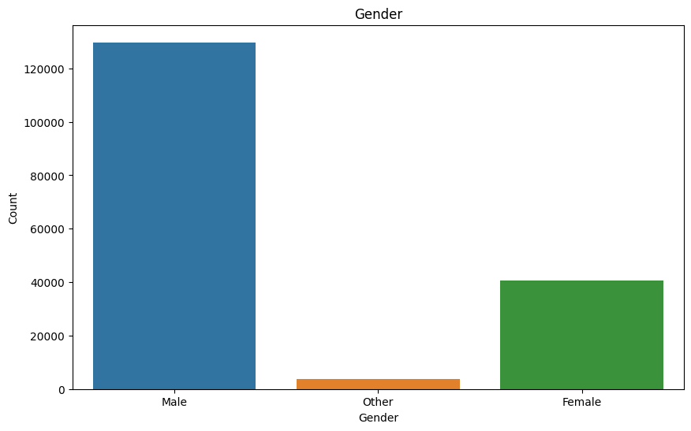

```python
#plot

countplot(x_label='Gender', y_label='Count', title='Gender', variable_one= 'member_gender')
```

> Observation: Male riders are the **highest** in numbers by a large difference. They have a total of 120k+.

## 2- Trip Duration Distribution

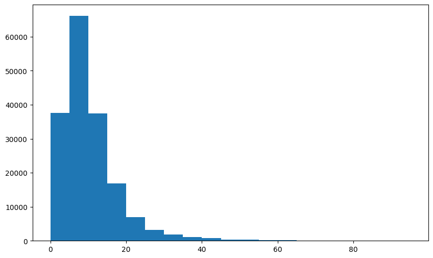

```python
#plot

histplot(bins = np.arange(0, 100, 5), x_label='Trip Duration (Minutes)', y_label='Count', title='Trip Duration (Minutes)', variable_one= 'duration_min')
```

> Observation: Trip durations usually **take** on average 5-15 mins. Trips longer than 30 mins are very rare.

## 3- User Types Count

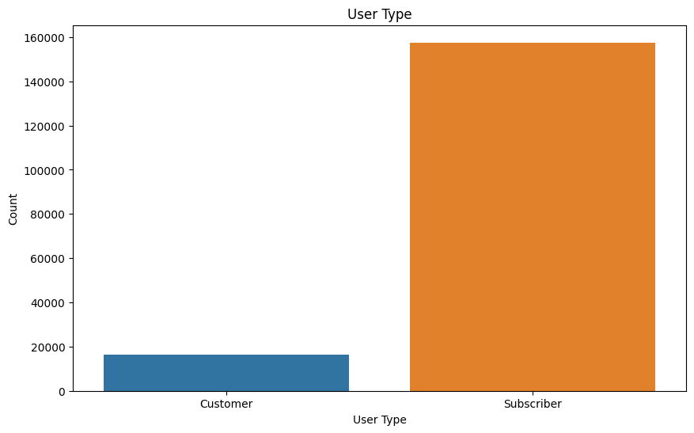

```python
#plot

countplot(x_label='User Type', y_label='Count', title='User Type', variable_one= 'user_type')
```

> Observation: **Most** riders are of type "Subscribers", they are more than 150k.

## 4- Bike Trips By Days

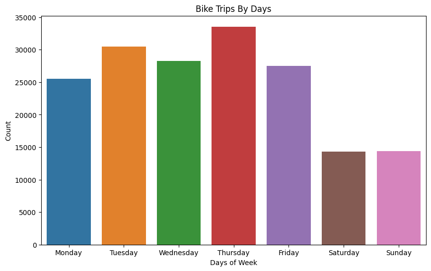

```python
days_order = ['Monday', 'Tuesday', 'Wednesday', 'Thursday', 'Friday', 'Saturday', 'Sunday']

countplot(x_label='Days of Week', y_label='Count', title='Bike Trips By Days', variable_one= 'weekday', order=days_order);
```

> Observation: There are more trips on weekdays (Mostly on Thursday) than weekends, very **interesting**!

## 5- Age

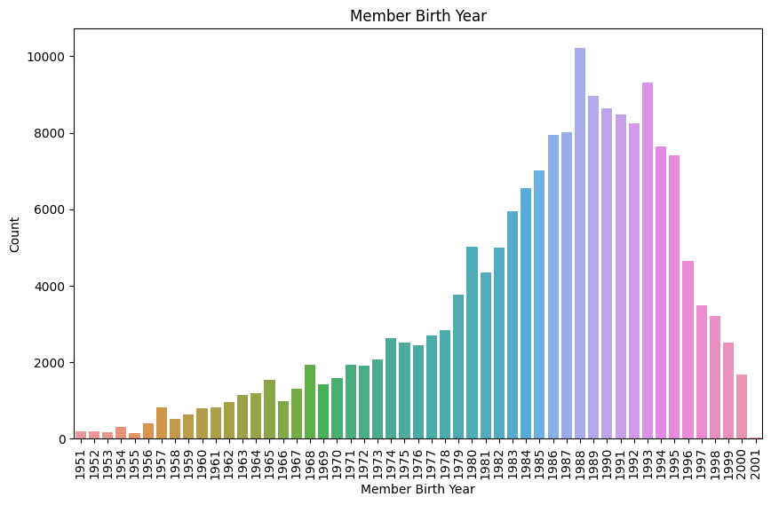

```python
#plot

countplot(rotate_x_label=True, x_label='Member Birth Year', y_label='Count', title='Member Birth Year', variable_one= 'member_birth_year');
```

> Observation: Riders of age **29-35** take more trips than others, which is not very surprising since they are younger and probably have jobs.

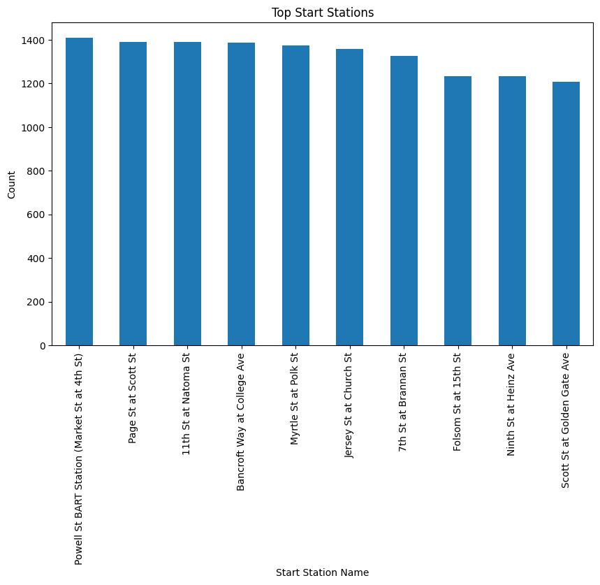

```python
#plot
plt.figure(figsize = (10, 6))

blue = sns.color_palette()[0]

top_start_staions = df_cleaned.groupby('start_station_name')['duration_min'].max().sort_values(ascending=False).head(10)
top_start_staions.plot(kind='bar')
plt.title("Top Start Stations")
plt.xlabel("Start Station Name")
plt.ylabel("Count");
```

## 5- Top Start hours

```python
# add start_hour column
df_cleaned['start_hour'] = df_cleaned['start_time'].dt.hour
```

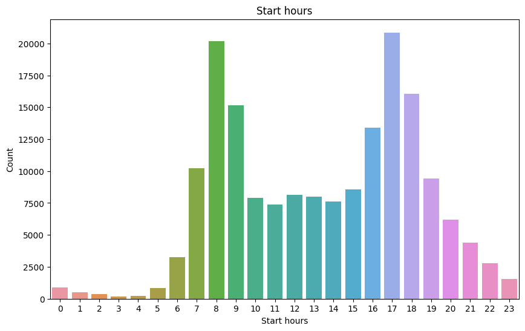

```python
#plot

countplot(x_label='Start hours', y_label='Count', title='Start hours', variable_one= 'start_hour');
```

> Observation: Start hours 8AM and 5PM have the most trip, this actually **makes sense** since it's the typical work hours!

### Of the features you investigated, were there any unusual distributions? Did you perform any operations on the data to tidy, adjust, or change the form of the data? If so, why did you do this?

> No unusual distribution so far. I had to perform some data cleaning such as removing missing values, converting column types and creating new features/columns.

# Bivariate Exploration

## 1- Trips duration vs Gender

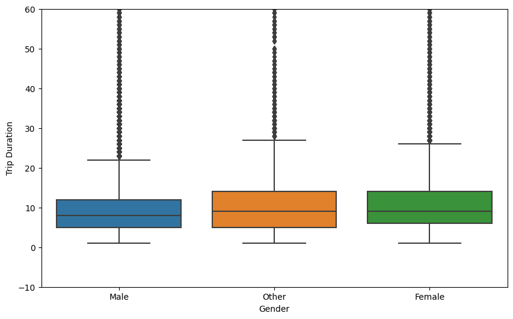

```python
#plot

plt.figure(figsize = (10, 6))

sns.boxplot(data = df_cleaned, x = 'member_gender', y = 'duration_min')
plt.xlabel('Gender')
plt.ylabel('Trip Duration')
plt.ylim([-10, 60])
plt.show();
```

> Observation: **Interestingly**, "Female" and "Others" gender take longer trips than "Male" gender, they take from 5-25 minutes.

## 2- Trips duration vs Age (1)

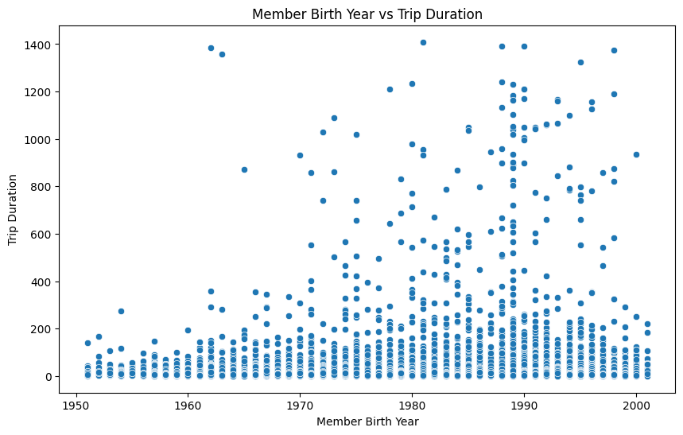

```python
#plot

plt.figure(figsize = (10, 6))

sns.scatterplot(data = df_cleaned, x ='member_birth_year', y = 'duration_min')
plt.title('Member Birth Year vs Trip Duration')
plt.ylabel('Trip Duration')
plt.xlabel('Member Birth Year')
plt.show();
```

## 2- Trips duration vs Age (2)

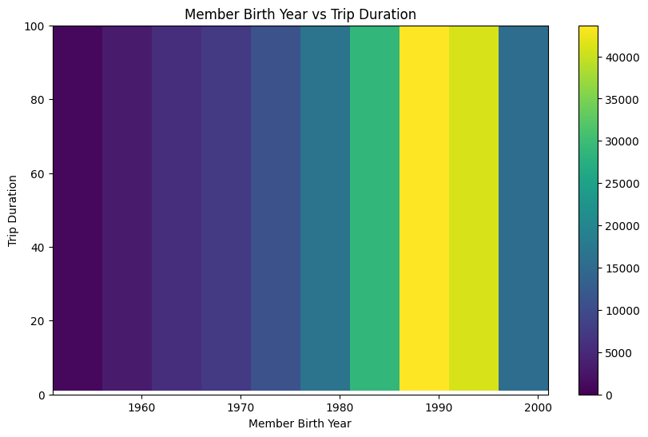

```python
#plot

plt.figure(figsize = (10, 6))

plt.hist2d(data = df_cleaned, x='member_birth_year', y='duration_min')
plt.title('Member Birth Year vs Trip Duration')
plt.colorbar()
plt.ylim([0, 100])
plt.xlabel('Member Birth Year')
plt.ylabel('Trip Duration');
```

### Did you observe any interesting relationships between the other features (not the main feature(s) of interest)?

> None

# Multivariate Exploration

## 1- Trip duration vs Gender vs Age

```python
# reusable plotting functions
def pointplot(rotate_x_label = False, variable_one = '',variable_two = '',variable_three = '', x_label = '', y_label = '', title = '', order=None):
    plt.figure(figsize = (10, 6))
    if (rotate_x_label == True):
        plt.xticks(rotation=90)
        ax=sns.pointplot(data = df_cleaned, x = variable_one, y = variable_two, hue=variable_three, errorbar=None, order=order )
        ax.set(xlabel=x_label,
                ylabel=y_label,
                title=title)
        plt.show();

    else:
        ax=sns.pointplot(data = df_cleaned, x = variable_one, order=order)
        ax.set(xlabel=x_label,
                ylabel=y_label,
                title=title)
        plt.show();
```

```python
# see max duration value
highest_duration = df_cleaned.duration_min.unique().max()
highest_duration
```

```
1409
```

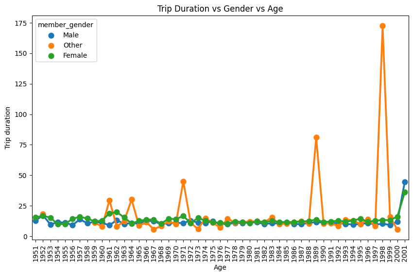

```python
#plot

pointplot(rotate_x_label=True,variable_one='member_birth_year',variable_two='duration_min',variable_three='member_gender',x_label='Age',y_label='Trip duration',title='Trip Duration vs Gender vs Age')
```

## 2- Trip duration vs Gender vs Start Hour

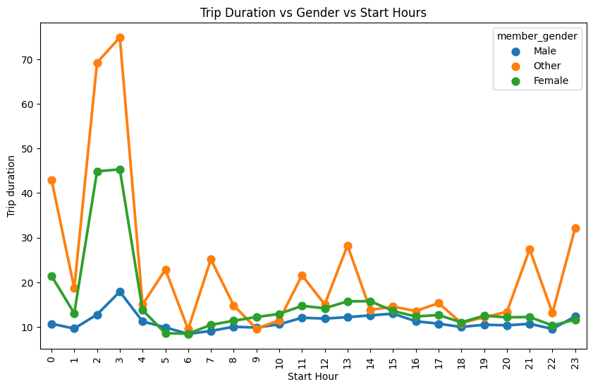

```python
#plot

pointplot(rotate_x_label=True,variable_one='start_hour',variable_two='duration_min',variable_three='member_gender',x_label='Start Hour',y_label='Trip duration',title='Trip Duration vs Gender vs Start Hours')
```

## 3- Trip Duration vs Gender vs Weekday

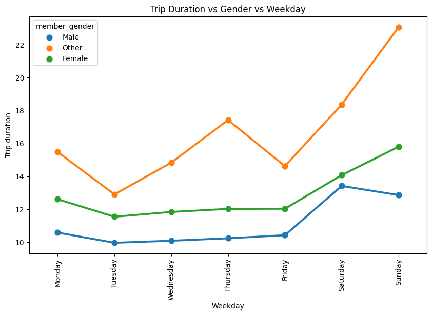

```python
#plot
days_order = ['Monday', 'Tuesday', 'Wednesday', 'Thursday', 'Friday', 'Saturday', 'Sunday']

pointplot(order=days_order, rotate_x_label=True,variable_one='weekday',variable_two='duration_min',variable_three='member_gender',x_label='Weekday',y_label='Trip duration',title='Trip Duration vs Gender vs Weekday')
```

> Observation: Riders have longer trips on weekends, for all genders. "Other" gender has the longest trips.

## 4- Trip Duration vs User Type vs Weekday

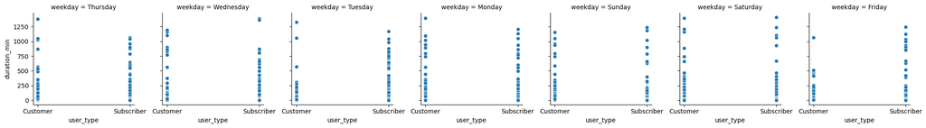

```python
#plot

g = sns.FacetGrid(data = df_cleaned, col = "weekday")
g.map(sns.scatterplot, "user_type", "duration_min")
plt.show();
```

### Talk about some of the relationships you observed in this part of the investigation. Were there features that strengthened each other in terms of looking at your feature(s) of interest?

> These charts conveyed the relationships we analyzed earlier. We've seen how weekday impacts trip duration (longer trips on weekends). We've also seen how gender and age impact trip duration, especially gender group "Other".

## References:

- https://seaborn.pydata.org/generated/seaborn.FacetGrid.html
- https://www.kaggle.com/datasets/chirag02/ford-gobike-2019feb-tripdata/code